# NFE2L2 activitiy in adult NAFLD cohort

Christian H. Holland[^1]

21 August, 2020

# Library and sources

These libraries and sources are used in this analysis

```r
library(tidyverse)
library(GEOquery)
library(edgeR)
library(dorothea)
library(biobroom)
library(here)
library(ggpubr)
library(viper)

source(here("src/utils.R"))
```

# Data processing

## Download meta data

Meta data are downloaded from Gene Expression Omnibus via the Bioconductor package GEOquery.

```r
df = getGEO("GSE130970")

meta = df$GSE130970_series_matrix.txt.gz %>%
  pData() %>%
  rownames_to_column("sample") %>%
  as_tibble() %>%
  select(sample = title, fibrosis = `fibrosis stage:ch1`,
         lobular_inflammation = `lobular inflammation grade:ch1`,
         nafld = `nafld activity score:ch1`, gender = `Sex:ch1`,
         steatosis = `steatosis grade:ch1`, age = `age at biopsy:ch1`,
         ballooning = `cytological ballooning grade:ch1`) %>%
  mutate(fibrosis = fct_inseq(fibrosis),
         lobular_inflammation = fct_inseq(lobular_inflammation),
         nafld = fct_inseq(nafld),
         gender = as_factor(str_to_lower(gender)),
         steatosis = fct_inseq(steatosis),
         age = as.numeric(age),
         ballooning = fct_inseq(ballooning)) %>%
  mutate(nafld = factor(str_c("stage", nafld, sep="_"),
                        levels = str_c("stage", c(0:6), sep = "_")))

saveRDS(meta, here("output/adult_nafld_cohort/meta.rds"))

meta
```

| sample | fibrosis | lobular_inflammation | nafld | gender | steatosis | age | ballooning |
| --- | --- | --- | --- | --- | --- | --- | --- |
| 440349.1.X_1 | 3 | 1 | stage_5 | f | 2 | 80 | 2 |
| 440350.1.X_1 | 3 | 1 | stage_4 | f | 1 | 48 | 2 |
| 440351.1.X_4 | 3 | 1 | stage_5 | f | 2 | 65 | 2 |
| 440352.1.X_4 | 3 | 1 | stage_5 | f | 2 | 53 | 2 |
| 440353.1.X_4 | 3 | 2 | stage_6 | f | 2 | 61 | 2 |
| 440354.1.X_4 | 3 | 2 | stage_6 | f | 2 | 46 | 2 |
| 440355.1.X_4 | 3 | 1 | stage_5 | f | 3 | 56 | 1 |
| 440357.1.X_5 | 3 | 1 | stage_6 | f | 3 | 55 | 2 |
| 440375.1.X_8 | 3 | 1 | stage_4 | f | 1 | 60 | 2 |
| 440376.1.X_1 | 3 | 1 | stage_4 | m | 2 | 56 | 1 |

[output cut: 68 more lines]

## Process count matrix

```r
# read count data with entrez gene ids
count_mat_entrez = read_csv(here("data/adult_nafld_cohort/GSE130970_all_sample_salmon_tximport_counts_entrez_gene_ID.csv"))

# translate gene ids to hgnc symbols
count_mat = count_mat_entrez %>%
  mutate(entrez_id = as.character(entrez_id)) %>%
  rename(gene = entrez_id) %>%
  translate_gene_ids(from = "entrez_hgnc", to = "symbol_hgnc") %>%
  # summarize over multiple genes - takes a while
  drop_na(gene) %>%
  group_by(gene) %>%
  summarise(across(where(is.numeric), median)) %>%
  data.frame(row.names = 1, check.names = F)

saveRDS(count_mat, here("output/adult_nafld_cohort/count_mat.rds"))
```

# Normalization

Count matrix is normalized via voom which filters for low read counts, performs a TMM normalization and transforms the values to logCPMs.

```r
meta = readRDS(here("output/adult_nafld_cohort/meta.rds"))
count_mat = readRDS(here("output/adult_nafld_cohort/count_mat.rds"))

# check if count and meta data and matrix correspond to each other
stopifnot(identical(colnames(count_mat), as.character(meta$sample)))

dge_obj = count_mat %>%
  DGEList(group = meta$nafld)

# filter low read counts, TMM normalization and logCPM transformation
norm_expr = voom_normalization(dge_obj)

saveRDS(norm_expr, here("output/adult_nafld_cohort/norm_expr.rds"))
```

# TF activity inference

TF activities are inferred via the dorothe package.

```r
norm_expr = readRDS(here("output/adult_nafld_cohort/norm_expr.rds"))
meta = readRDS(here("output/adult_nafld_cohort/meta.rds"))

tf_scores = run_viper(norm_expr, dorothea_hs,
                      options = list(nes = T, method = "scale", minsize = 4,
                                     eset.filter = F, verbose=F), tidy = T) %>%
  as_tibble()
```

## TF activity of NFE2L2

Here we show how the activity of NFE2L2 changes with different lobular inflammation stages. To access the significance, an anova (including linear models) and correlation analysis is performed.

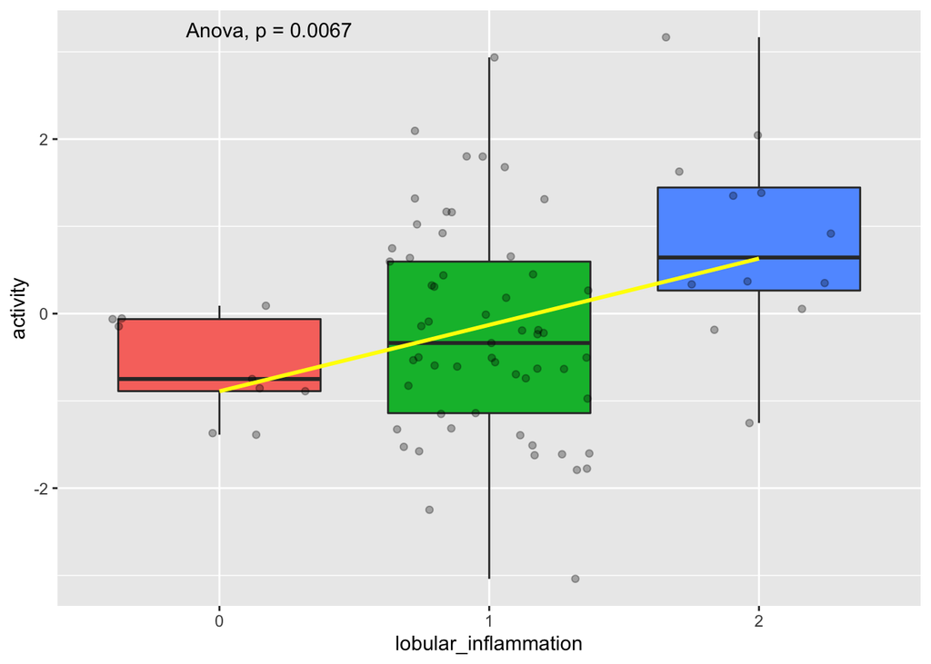

```r
a = tf_scores %>%
  left_join(meta, by="sample") %>%
  filter(tf %in% "NFE2L2")

a %>%
  ggplot(aes(x=lobular_inflammation, y=activity, fill=lobular_inflammation)) +
  geom_boxplot() +
  geom_jitter(alpha = 0.3) +
  theme(legend.position = "none") +
  ggpubr::stat_compare_means(method = "anova") +
  stat_compare_means(comparisons = list(c("none", "mild"), c("mild", "severe"),
                                        c("none", "severe"))) +
  geom_smooth(method = "lm", se = FALSE, color = "yellow", aes(group = 1))
```

```r
# anova
a %>%
  nest(data = -tf) %>%
  mutate(aov = data %>% map(~broom::tidy(
    aov(activity~lobular_inflammation, data = .)))) %>%
  select(-data) %>%
  unnest(aov)
```

| tf | term | df | sumsq | meansq | statistic | p.value |
| --- | --- | --- | --- | --- | --- | --- |
| NFE2L2 | lobular_inflammation | 2 | 13.85375 | 6.926877 | 5.355573 | 0.00669728 |
| NFE2L2 | Residuals | 75 | 97.00470 | 1.293396 | NA | NA |

```r
# anova post hoc test
a %>%
  nest(data = -tf) %>%
  mutate(tukey = data %>% map(~broom::tidy(
    TukeyHSD(aov(activity~lobular_inflammation, data = .))))) %>%
  unnest(tukey) %>%
  select(-data, -null.value)
```

| tf | term | contrast | estimate | conf.low | conf.high | adj.p.value |
| --- | --- | --- | --- | --- | --- | --- |
| NFE2L2 | lobular_inflammation | 1-0 | 0.3825929 | -0.5927993 | 1.357985 | 0.61817627 |
| NFE2L2 | lobular_inflammation | 2-0 | 1.4494982 | 0.2503752 | 2.648621 | 0.01377912 |
| NFE2L2 | lobular_inflammation | 2-1 | 1.0669054 | 0.2032062 | 1.930605 | 0.01154713 |

```r
# linear models
a %>%
  nest(data = -tf) %>%
  mutate(lm = data %>% map(~broom::tidy(
    lm(activity~lobular_inflammation, data = .)))) %>%
  unnest(lm) %>%
  filter(term != "(Intercept)") %>%
  select(-data)
```

| tf | term | estimate | std.error | statistic | p.value |
| --- | --- | --- | --- | --- | --- |
| NFE2L2 | lobular_inflammation1 | 0.3825929 | 0.4079238 | 0.9379028 | 0.351304963 |
| NFE2L2 | lobular_inflammation2 | 1.4494982 | 0.5014914 | 2.8903748 | 0.005029746 |

```r
# correlations
a %>%
  mutate_if(is.factor, as.numeric) %>%
  nest(data = -tf) %>%
  mutate(r = data %>% map(~broom::tidy(
    cor.test(~activity + lobular_inflammation, data = .,
             method = "spearman")))) %>%
  unnest(r) %>%
  select(-data)
```

| tf | estimate | statistic | p.value | method | alternative |
| --- | --- | --- | --- | --- | --- |
| NFE2L2 | 0.3373585 | 52401.03 | 0.002524048 | Spearman's rank correlation rho | two.sided |

## TF expression of NFE2L2

Here we show how the expression of NFE2L2 changes with different lobular inflammation stages. To access the significance, an anova (including linear models) and correlation analysis is performed.

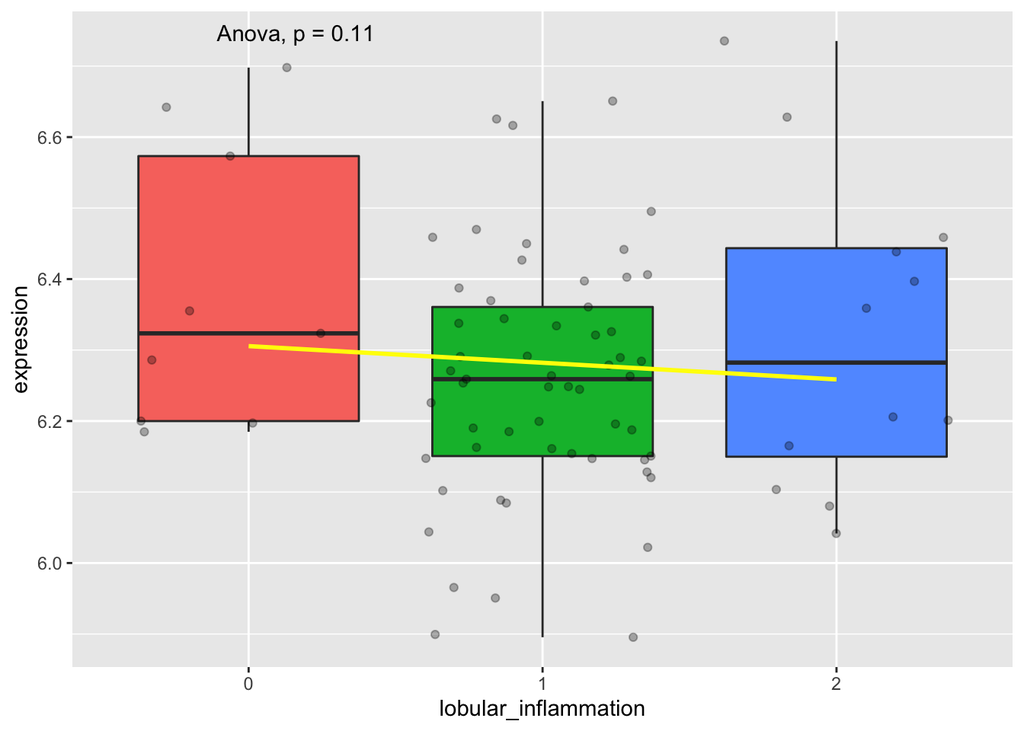

```r
e = norm_expr %>%
  tdy("gene", "sample", "expression") %>%
  left_join(meta, by="sample") %>%
  filter(gene %in% "NFE2L2")

e %>%
  ggplot(aes(x=lobular_inflammation, y=expression, fill=lobular_inflammation)) +
  geom_boxplot() +
  geom_jitter(alpha = 0.3) +
  theme(legend.position = "none") +
  stat_compare_means(comparisons = list(c("none", "mild"), c("mild", "severe"),
                                        c("none", "severe"))) +
  ggpubr::stat_compare_means(method = "anova") +
  geom_smooth(method = "lm", se = FALSE, color = "yellow", aes(group = 1))
```

```r
# anova
e %>%
  nest(data = -gene) %>%
  mutate(aov = data %>% map(~broom::tidy(
    aov(expression~lobular_inflammation, data = .)))) %>%
  select(-data) %>%
  unnest(aov)
```

| gene | term | df | sumsq | meansq | statistic | p.value |
| --- | --- | --- | --- | --- | --- | --- |
| NFE2L2 | lobular_inflammation | 2 | 0.1447712 | 0.07238558 | 2.243575 | 0.1131522 |
| NFE2L2 | Residuals | 75 | 2.4197627 | 0.03226350 | NA | NA |

```r
# anova post hoc test
e %>%
  nest(data = -gene) %>%
  mutate(tukey = data %>% map(~broom::tidy(
    TukeyHSD(aov(expression~lobular_inflammation, data = .))))) %>%
  unnest(tukey) %>%
  select(-data, -null.value)
```

| gene | term | contrast | estimate | conf.low | conf.high | adj.p.value |
| --- | --- | --- | --- | --- | --- | --- |
| NFE2L2 | lobular_inflammation | 1-0 | -0.12721726 | -0.28126995 | 0.02683543 | 0.1255808 |
| NFE2L2 | lobular_inflammation | 2-0 | -0.06663981 | -0.25602838 | 0.12274876 | 0.6786317 |
| NFE2L2 | lobular_inflammation | 2-1 | 0.06057746 | -0.07583452 | 0.19698943 | 0.5405984 |

```r
# linear models
e %>%
  nest(data = -gene) %>%
  mutate(lm = data %>% map(~broom::tidy(lm(expression~lobular_inflammation,
                                           data = .)))) %>%
  unnest(lm) %>%
  filter(term != "(Intercept)") %>%
  select(-data)
```

| gene | term | estimate | std.error | statistic | p.value |
| --- | --- | --- | --- | --- | --- |
| NFE2L2 | lobular_inflammation1 | -0.12721726 | 0.06442717 | -1.9745903 | 0.05199619 |
| NFE2L2 | lobular_inflammation2 | -0.06663981 | 0.07920517 | -0.8413568 | 0.40282273 |

```r
# correlation
e %>%
  mutate_if(is.factor, as.numeric) %>%
  nest(data = -gene) %>%
  mutate(r = data %>% map(~tidy(cor.test(~expression + lobular_inflammation,
                                         data = ., method = "spearman")))) %>%
  unnest(r) %>%
  select(-data)
```

| gene | estimate | statistic | p.value | method | alternative |
| --- | --- | --- | --- | --- | --- |
| NFE2L2 | -0.06434937 | 84167.68 | 0.5756682 | Spearman's rank correlation rho | two.sided |

[^1]: Faculty of Medicine, Institute of Computational Biomedicine, Heidelberg University, Bioquant, Heidelberg, Germany, christian.holland@bioquant.uni-heidelberg.de